# Supervised PCA Walkthrough with pathwayPCA

Gabriel Odom

2018-04-24

# Overview

This vignette is half of the third chapter in the “Pathway Significance Testing with `pathwayPCA`” workflow. This vignette builds on the material covered in the [“Import and Tidy Data”](https://gabrielodom.github.io/pathwayPCA/articles/Importing_Data.html) and [“Creating -Omics Data Objects”](https://gabrielodom.github.io/pathwayPCA/articles/Create_Omics_Objects.html) vignettes. This guide will outline the major steps needed analyze `Omics*`-class objects with pathway-level supervised PCA. We will consider three examples: survival, regression, and binary responses. The main goal of pathway supervised PCA is to discover potential relationships between pathways (bundles of genes) and a response. This package (in its current form) should not be used for prediction, or regressing on multiple variables, but should simply be used to screen or identify potential pathways for futher inspection.

### Outline

Before we move on, we will outline our steps. After reading this vignette, you should

1. Understand the basics of the supervised PCA pathway-significance testing approach.
2. Be able to apply supervised PCA to analyze survival (`OmicsSurv`), regression (`OmicsReg`), or classification (`OmicsCateg`) data containers.

### Load Packages

Before we begin, make sure you have the latest version of the package. In order to install a package from GitHub, you will need the `devtools::` package (https://github.com/r-lib/devtools) and either [Rtools](https://cran.r-project.org/bin/windows/Rtools/) (for Windows) or [Xcode](https://developer.apple.com/xcode/) (for Mac). Then you can install the development version of the [`pathwayPCA` package](https://github.com/gabrielodom/pathwayPCA) from [GitHub](https://github.com/):

```
devtools::install_github("gabrielodom/pathwayPCA")
```

```r
library(pathwayPCA)
library(parallel)
```

### Load `Omics*` Data

```r
colon_OmicsSurv
```

```
#> Formal class 'OmicsSurv' [package "pathwayPCA"] with 4 slots
#>   ..@ eventTime    : num [1:250] 64.9 59.8 62.4 54.5 46.3 ...
#>   ..@ eventObserved: logi [1:250] FALSE FALSE FALSE FALSE TRUE FALSE ...
#>   ..@ assayData_df :Classes 'tbl_df', 'tbl' and 'data.frame':    250 obs. of  656 variables:
#>   ..@ pathwaySet   :List of 3
#>   .. ..- attr(*, "class")= chr [1:2] "pathwaySet" "list"
```

# Clean Up the Pathway List

The analysis functions within the `pathwayPCA::` package subset the feature data frame by the genes in each pathway. Therefore, if we have genes in the pathways that aren’t recorded in the data frame, then we will necessarily create missing (`NA`) predictors. To circumvent this issue, we should check if each gene in each pathway is recorded in the data frame, and remove the genes for which we have not recorded expression levels.

## Calculate Pathway-Specific Model $p$-Values

We now have a clean set of `Omics*` objects. We will

1. Extract the first principal components from each expressed pathway in the MS design matrix
2. Test their association with the response matrix or vector
3. Adjust the pathway $p$-values for False Discovery Rate (FDR)
4. Return a sorted data frame of the adjusted $p$-values for each pathway

Of note: we use the FDR adjustments executed in the `mt.rawp2adjp` function from the Bioconductor package [`multtest`](https://www.bioconductor.org/packages/3.7/bioc/manuals/multtest/man/multtest.pdf). We copied the code from this function into our package, and made some slight modifications. However, we do not depend on this package directly. We acknowledge their work in this area and express our gratitude.

### Survival Response

```r
a <- Sys.time()
surv_pVals_df <- superPCA_pVals(object = colon_OmicsSurv,
                                parallel = TRUE,
                                numCores = 2,
                                adjustpValues = TRUE,
                                adjustment = c("Hoch", "SidakSD"))
```

```
#> Of the 676 unique genes in the input pathway set, 9.0% were not expressed in
#>   the input data and were therefore removed.
#> After trimming unexpressed genes from the 15 supplied pathways, we removed 0
#>   pathway(s) because they contained 3 or fewer genes.
#> Of the 656 measured genes in the input data frame, 93.8% were included in at
#>   least one pathway after trimming.
#> Initializing Computing Cluster
#> DONE
#> Calculating Pathway Test Statistics in Parallel
#> DONE
#> Calculating Pathway Critical Values in Parallel
#> DONE
#> Calculating Pathway p-Values
#> Adjusting p-Values and Sorting Pathway p-Value Data Frame
#> DONE
```

```r
Sys.time() - a
```

```
#> Time difference of 4.832555 secs
```

### Regression Response

We will use the Holm (1979) and Benjamini and Hochberg (1995) FDR-adjustment procedures.

```r
b <- Sys.time()
reg_pVals_df <- superPCA_pVals(object = colon_OmicsReg,
                               parallel = TRUE,
                               numCores = 2,
                               adjustpValues = TRUE,
                               adjustment = c("Holm", "BH"))
```

```
#> Of the 676 unique genes in the input pathway set, 9.0% were not expressed in
#>   the input data and were therefore removed.
#> After trimming unexpressed genes from the 15 supplied pathways, we removed 0
#>   pathway(s) because they contained 3 or fewer genes.
#> Of the 656 measured genes in the input data frame, 93.8% were included in at
#>   least one pathway after trimming.
#> Initializing Computing Cluster
#> DONE
#> Calculating Pathway Test Statistics in Parallel
#> DONE
#> Calculating Pathway Critical Values in Parallel
#> DONE
#> Calculating Pathway p-Values
#> Adjusting p-Values and Sorting Pathway p-Value Data Frame
#> DONE
```

```r
Sys.time() - b
```

```
#> Time difference of 4.278482 secs
```

### Binary Classification Response

We will use the Sidak Single-Step and Benjamini and Yekutieli (2001) FDR-adjustment procedures.

```r
d <- Sys.time()
categ_pVals_df <- superPCA_pVals(object = colon_OmicsCateg,
                                 parallel = TRUE,
                                 numCores = 2,
                                 adjustpValues = TRUE,
                                 adjustment = c("SidakSS", "BY"))
```

```
#> Of the 676 unique genes in the input pathway set, 9.0% were not expressed in
#>   the input data and were therefore removed.
#> After trimming unexpressed genes from the 15 supplied pathways, we removed 0
#>   pathway(s) because they contained 3 or fewer genes.
#> Of the 656 measured genes in the input data frame, 93.8% were included in at
#>   least one pathway after trimming.
#> Initializing Computing Cluster
#> DONE
#> Calculating Pathway Test Statistics in Parallel
#> DONE
#> Calculating Pathway Critical Values in Parallel
#> DONE
#> Calculating Pathway p-Values
#> Adjusting p-Values and Sorting Pathway p-Value Data Frame
#> DONE
```

```r
Sys.time() - d
```

```
#> Time difference of 5.903988 secs
```

## Subset the Top Pathways

Now that we have the pathway-specific $p$-values, we can inspect the top pathways by significance. We will first subset the data frame returned by the `superPCA_pVals()` function, then plot the most significant $p$-values using the `ggplot2::` package. For graphics, we will need two new packages:

```r
library(tidyverse)
library(reshape2)
```

For each pathway $p$-value data frame, we will select the top pathways, and transform the data for better graphics. Then, we will plot the pathway $p$-values for the most significant pathways as a horizontal bar chart. The thick vertical black line is at $p = 0.05$, and the thin vertical black line is at $p = 0.10$.

### Significant Survival Pathways

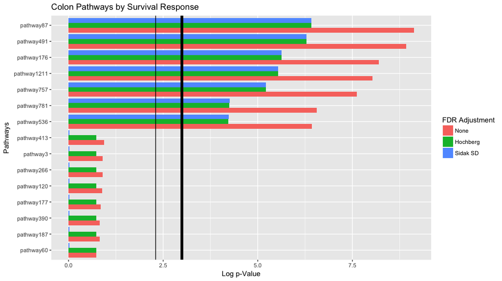

```r
# Melt the data
surv_melt_df <- surv_pVals_df %>%
  select(-terms, - setsize, -trim_size) %>%
  melt(id.vars = "pathways") %>%
  mutate(score = -log(value)) %>%
  mutate(pathways = factor(pathways,
                           levels = rev(unique(pathways)),
                           ordered = TRUE))

# Plot Melted Data
ggplot(surv_melt_df) +
  aes(x = pathways, y = score, fill = variable) +
  geom_bar(stat = "identity", position = "dodge") +
  scale_fill_discrete(name = "FDR Adjustment",
                      breaks = c("rawp", "Hochberg", "SidakSD"),
                      labels = c("None", "Hochberg", "Sidak SD")) +
  ggtitle("Colon Pathways by Survival Response") +
  xlab("Pathways") +
  ylab("Log p-Value") +
  geom_hline(yintercept = -log(0.05), size = 2) +
  geom_hline(yintercept = -log(0.1)) +
  coord_flip()
```

### Significant Regression Pathways

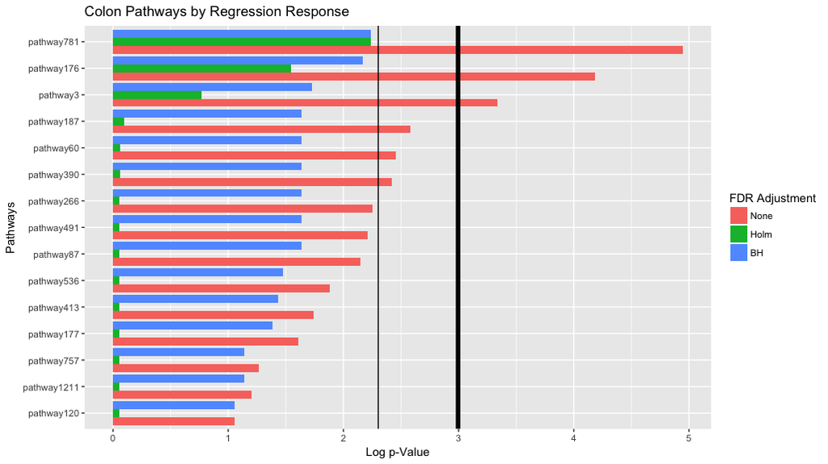

```r
# Melt the data
reg_melt_df <- reg_pVals_df %>%
  select(-terms, - setsize, -trim_size) %>%
  melt(id.vars = "pathways") %>%
  mutate(score = -log(value)) %>%
  mutate(pathways = factor(pathways,
                           levels = rev(unique(pathways)),
                           ordered = TRUE))

# Plot Melted Data
ggplot(reg_melt_df) +
  aes(x = pathways, y = score, fill = variable) +
  geom_bar(stat = "identity", position = "dodge") +
  scale_fill_discrete(name = "FDR Adjustment",
                      breaks = c("rawp", "Holm", "BH"),
                      labels = c("None", "Holm", "BH")) +
  ggtitle("Colon Pathways by Regression Response") +
  xlab("Pathways") +
  ylab("Log p-Value") +
  geom_hline(yintercept = -log(0.05), size = 2) +
  geom_hline(yintercept = -log(0.1)) +
  coord_flip()
```

### Significant Binary Classification Pathways

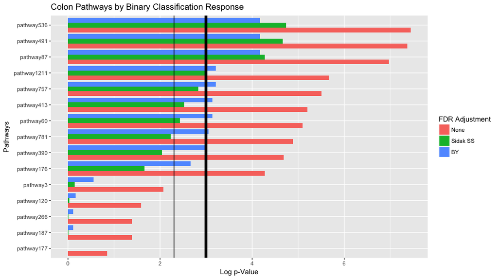

```r
# Melt the data
categ_melt_df <- categ_pVals_df %>%
  select(-terms, - setsize, -trim_size) %>%
  melt(id.vars = "pathways") %>%
  mutate(score = -log(value)) %>%
  mutate(pathways = factor(pathways,
                           levels = rev(unique(pathways)),
                           ordered = TRUE))

# Plot Melted Data
ggplot(categ_melt_df) +
  aes(x = pathways, y = score, fill = variable) +
  geom_bar(stat = "identity", position = "dodge") +
  scale_fill_discrete(name = "FDR Adjustment",
                      breaks = c("rawp", "SidakSS", "BY"),
                      labels = c("None", "Sidak SS", "BY")) +
  ggtitle("Colon Pathways by Binary Classification Response") +
  xlab("Pathways") +
  ylab("Log p-Value") +
  geom_hline(yintercept = -log(0.05), size = 2) +
  geom_hline(yintercept = -log(0.1)) +
  coord_flip()
```